# BikeSharingAnalysis

## FINAL MODEL ARUMA(8,0,0) S=7

## (1 - 0.4043B - 0.01801B^2 - 0.0225B^3 - 0.0428B^4 + 0.0060B^5 - 0.0304B^6 + 0.5069B^7 - 0.2151B^8)(1 - B^7)X_t = a_t

### Rolling Window for 1 week for FINAL MODEL ARUMA(8,0,0) S=7 => “The Rolling Window RMSE is: 1973.381”

## Note ROLLING WINDOW RMSE we cannot get for Multivariate processes, So I only got the rolling window RMSE for the simpler Univariate models.

```
## [1]  0.40432768  0.01801666  0.02246405  0.04287993 -0.00599795  0.03044390
## [7] -0.50685544  0.21513204
```

### Rolling Window for 26 week for FINAL MODEL ARUMA(8,0,0) S=7 => “The Rolling Window RMSE is: 2274.046”

### Rolling Window for 26 week for MODEL AR(8) => “The Rolling Window RMSE is: 3712.421”

### Rolling Window for 1 week for MODEL AR(8) => “The Rolling Window RMSE is: 4229.392”

### Checking for missing values (MCAR)

```
## [1] 2922   30
```

```
## [1] 48673
```

```
## 'data.frame':    2922 obs. of  30 variables:
##  $ date             : chr  "2011-01-01" "2011-01-02" "2011-01-03" "2011-01-04" ...
##  $ temp_avg         : num  NA NA NA NA NA NA NA NA NA NA ...
##  $ temp_min         : num  -1.57 0.88 -3.44 -5.96 -4.29 ...
##  $ temp_max         : num  11.97 13.81 7.46 4.64 6.11 ...
##  $ temp_observ      : num  2.77 7.33 -3.06 -3.1 -1.77 ...
##  $ precip           : num  0.0693 1.0373 1.8788 0 0 ...
##  $ wind             : num  2.58 3.92 3.62 1.8 2.95 ...
##  $ wt_fog           : num  1 1 NA NA NA NA 1 1 NA NA ...
##  $ wt_heavy_fog     : num  NA 1 NA NA NA NA NA 1 NA NA ...
##  $ wt_thunder       : num  NA NA NA NA NA NA NA NA NA NA ...
##  $ wt_sleet         : num  NA NA NA NA NA NA NA NA NA NA ...
##  $ wt_hail          : num  NA NA NA NA NA NA NA NA NA NA ...
##  $ wt_glaze         : num  NA NA NA NA NA NA NA NA NA NA ...
##  $ wt_haze          : num  1 NA NA NA NA NA 1 1 NA NA ...
```

[output cut: 16 more lines]

[figure not shown]

# VAR Model

```r
no_missing_values = apply(BikeSharing, 2, function(x) all(complete.cases(x)))
columns_no_missing = names(BikeSharing)[no_missing_values]

# All columns
colnames(BikeSharing)
```

```
##  [1] "date"              "temp_avg"          "temp_min"
##  [4] "temp_max"          "temp_observ"       "precip"
##  [7] "wind"              "wt_fog"            "wt_heavy_fog"
## [10] "wt_thunder"        "wt_sleet"          "wt_hail"
## [13] "wt_glaze"          "wt_haze"           "wt_drift_snow"
## [16] "wt_high_wind"      "wt_mist"           "wt_drizzle"
## [19] "wt_rain"           "wt_freeze_rain"    "wt_snow"
## [22] "wt_ground_fog"     "wt_ice_fog"        "wt_freeze_drizzle"
## [25] "wt_unknown"        "casual"            "registered"
## [28] "total_cust"        "holiday"           "precip_L1"
```

```r
# Columns with no missing values
print(columns_no_missing)
```

```
## [1] "date"        "temp_min"    "temp_max"    "temp_observ" "precip"
## [6] "wind"        "total_cust"  "holiday"     "precip_L1"
```

```r
# date, total_cust, temp_min, temp_max, temp_observ, precip, wind
```

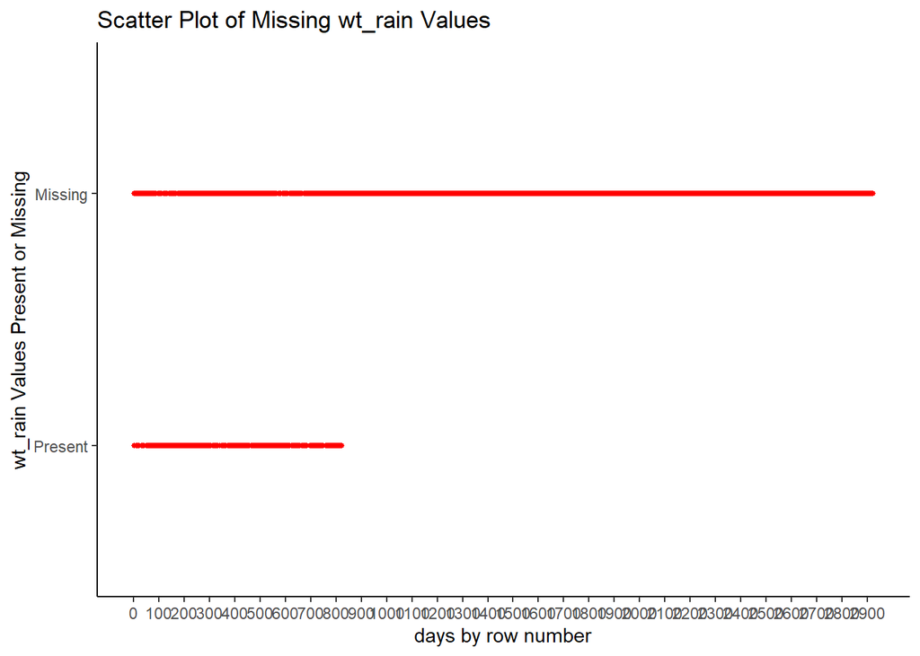

```r
data <- data.frame(x = is.na(BikeSharing$wt_rain))

gg <- ggplot(data, aes(x = 1:nrow(data), y = x)) +
  geom_point(size = 1, height = .5, width = .5, color = "red") +
  xlab("days by row number") +
 ylab("wt_rain Values Present or Missing") +
 labs(title = "Scatter Plot of Missing wt_rain Values", size = 10) +
 scale_y_discrete(labels = c("Present", "Missing")) +
 scale_x_continuous(breaks = seq(0, nrow(data), by = 100)) +
 theme(axis.text.x = element_text(angle = 90, hjust  = 1)) +
 theme_classic()
gg
```

```r
# Select columns with no missing values excluding 'date' and 'precip_L1'
variables = c("total_cust", "temp_min", "temp_max", "temp_observ", "precip", "wind", "holiday")
BikeSharingSelected = BikeSharing[variables]

# Leave out the last 182 values for the ASE calculation
BikeSharingSmall = head(BikeSharingSelected, -182)

# Prepare the data for the VAR model
BikeSharingDF = data.frame(BikeSharingSmall[,-1]) # Exclude 'total_cust' for independent variables
TotalCust = BikeSharingSmall$total_cust
```

```r
# Double check we have all the dependent variables correctly saved to the dataframe
head(BikeSharingDF)
```

```
##    temp_min  temp_max temp_observ     precip  wind holiday
## 1 -1.566667 11.973333    2.772727 0.06933333 2.575       0
## 2  0.880000 13.806667    7.327273 1.03734940 3.925       0
## 3 -3.442857  7.464286   -3.060000 1.87882353 3.625       0
## 4 -5.957143  4.642857   -3.100000 0.00000000 1.800       0
## 5 -4.293333  6.113333   -1.772727 0.00000000 2.950       0
## 6 -4.993333  4.233333   -4.245455 0.00000000 1.600       0
```

```r
VAR_Select_Bikeshare = VARselect(cbind(TotalCust, BikeSharingDF),lag.max = 10, type = "both")
VAR_Select_Bikeshare
```

```
## $selection
## AIC(n)  HQ(n)  SC(n) FPE(n)
##      9      3      2      9
##
## $criteria
##                   1            2            3            4            5
## AIC(n) 1.929196e+01 1.881508e+01 1.875050e+01 1.871591e+01 1.868596e+01
## HQ(n)  1.934127e+01 1.890274e+01 1.887652e+01 1.888027e+01 1.888868e+01
## SC(n)  1.942839e+01 1.905763e+01 1.909916e+01 1.917068e+01 1.924685e+01
## FPE(n) 2.389960e+08 1.483497e+08 1.390724e+08 1.343438e+08 1.303810e+08
##                   6            7            8            9           10
## AIC(n) 1.865703e+01 1.864557e+01 1.864942e+01 1.864429e+01 1.866279e+01
## HQ(n)  1.889811e+01 1.892499e+01 1.896720e+01 1.900042e+01 1.905727e+01
## SC(n)  1.932403e+01 1.941868e+01 1.952865e+01 1.962963e+01 1.975425e+01
## FPE(n) 1.266646e+08 1.252221e+08 1.257074e+08 1.250659e+08 1.274046e+08
```

```r
# Create the VAR model
VAR_BikeSharing = VAR(cbind(TotalCust, BikeSharingDF), lag.max = 10, type = "both", p = 9)

# Prediction
pred_VAR_7 = predict(VAR_BikeSharing, n.ahead = 7)
pred_VAR_182 = predict(VAR_BikeSharing, n.ahead = 182)
```

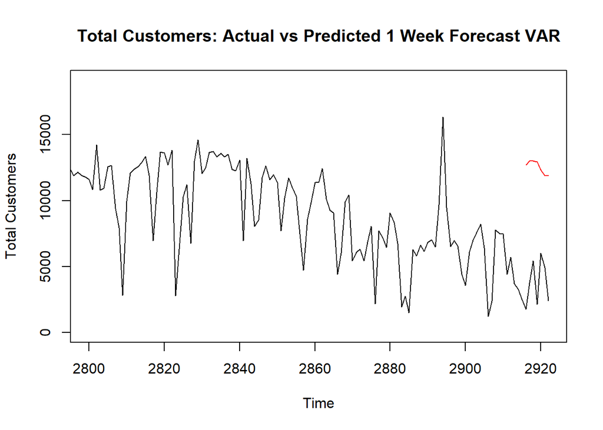

```r
# Plot the actual vs predicted 'total_cust'
plot(BikeSharing$total_cust, type = "l", main = "Total Customers: Actual vs Predicted 1 Week Forecast VAR", xlab = "Time", ylab = "Total Customers", xlim = c(2800, nrow(BikeSharing)))
lines((nrow(BikeSharing) - 6):nrow(BikeSharing), pred_VAR_7$fcst$TotalCust[,1], col = "red")
```

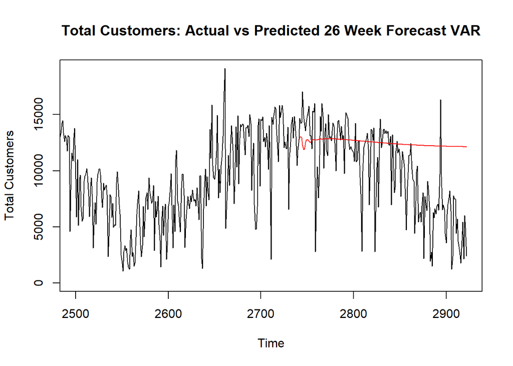

```r
# Plot the actual vs predicted 'total_cust' zoomed in on the last 1/6th of the timeline
plot(BikeSharing$total_cust, type = "l", main = "Total Customers: Actual vs Predicted 26 Week Forecast VAR", xlab = "Time", ylab = "Total Customers", xlim = c(2500, nrow(BikeSharing)))
lines((nrow(BikeSharing) - 181):nrow(BikeSharing), pred_VAR_182$fcst$TotalCust[,1], col = "red")
```

```r
# Calculate the Average Squared Error (ASE) for the prediction
ASE_VAR_7 = mean((tail(BikeSharing$total_cust, 7) - pred_VAR_7$fcst$TotalCust[,1])^2)
print(ASE_VAR_7)
```

```
## [1] 79799190
```

```r
ASE_VAR_182 = mean((tail(BikeSharing$total_cust, 182) - pred_VAR_182$fcst$TotalCust[,1])^2)
print(ASE_VAR_182)
```

```
## [1] 19615899
```

# MLP Model

```r
# Exclude the first 2,300 values from BikeSharingSmall and BikeSharingDF
BikeSharingSmallAdjusted = BikeSharingSmall[-(1:2300), ]
BikeSharingDFAdjusted = BikeSharingDF[-(1:2300), ]
```

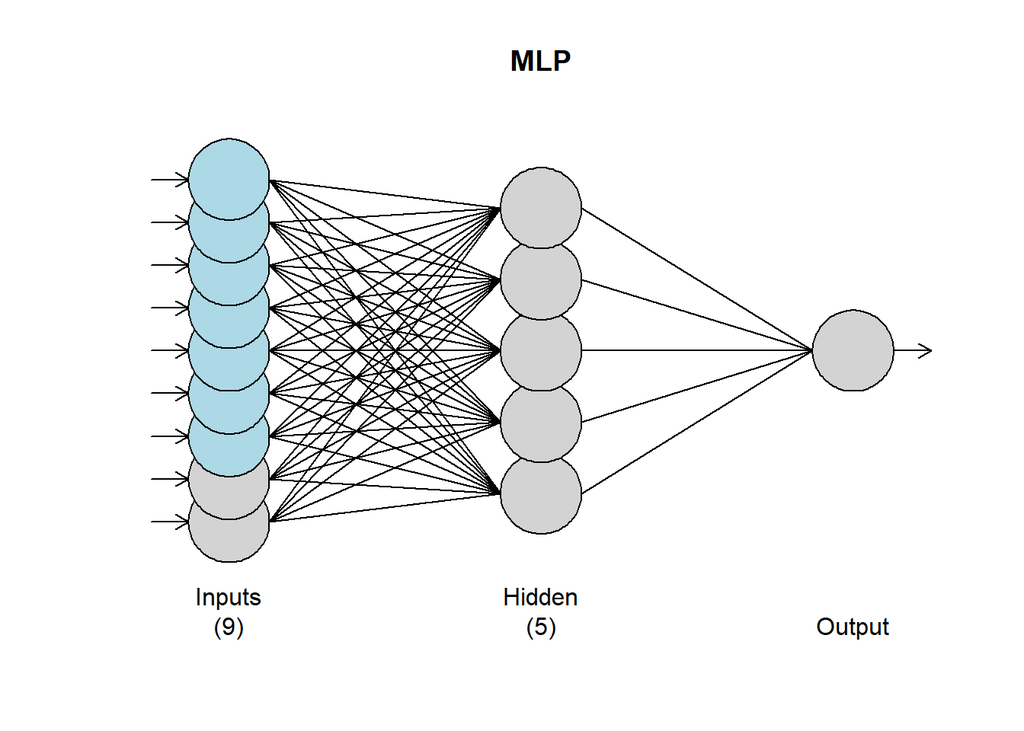

```r
fit_mlp = mlp(ts(BikeSharingSmallAdjusted$total_cust), reps = 7, comb = "median", xreg = BikeSharingDFAdjusted)
plot(fit_mlp)
```

```r
fore_mlp_182 = forecast(fit_mlp, h = 182, xreg = BikeSharingSelected[-(1:2300), -1])
fore_mlp_7 = forecast(fit_mlp, h = 7, xreg = BikeSharingSelected[-(1:2300), -1])
```

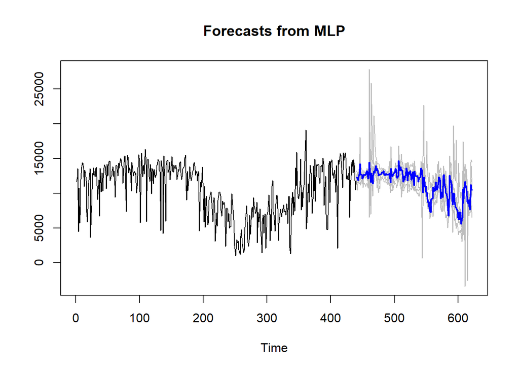

```r
plot(fore_mlp_182)
```

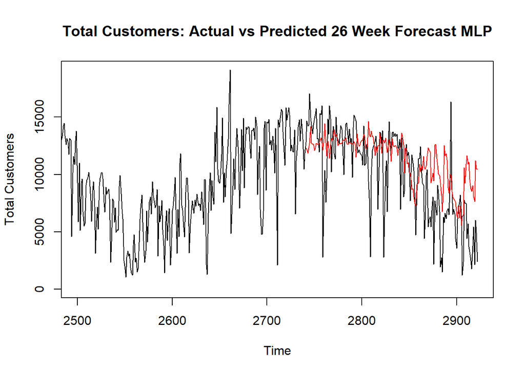

```r
# Plot the actual 'total_cust' values
plot(BikeSharing$total_cust, type = "l", main = "Total Customers: Actual vs Predicted 26 Week Forecast MLP", xlab = "Time", ylab = "Total Customers", xlim = c(2500, nrow(BikeSharing)))

# Add the MLP forecasted 'total_cust' values
lines((nrow(BikeSharing) - 181):nrow(BikeSharing), fore_mlp_182$mean, col = "red")
```

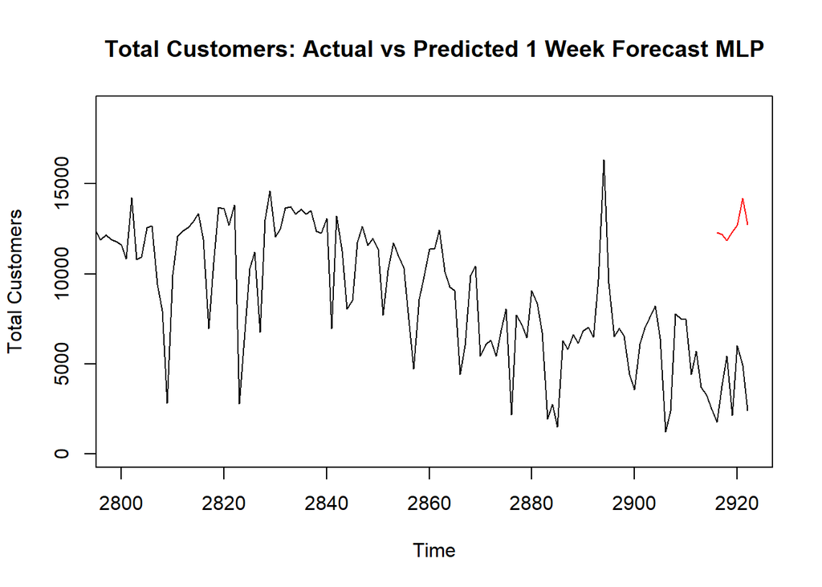

```r
# Plot the actual 'total_cust' values
plot(BikeSharing$total_cust, type = "l", main = "Total Customers: Actual vs Predicted 1 Week Forecast MLP", xlab = "Time", ylab = "Total Customers", xlim = c(2800, nrow(BikeSharing)))

# Add the MLP forecasted 'total_cust' values
lines((nrow(BikeSharing) - 6):nrow(BikeSharing), fore_mlp_7$mean, col = "red")
```

```r
ASE_mlp_182 = mean((tail(BikeSharing$total_cust, 182) - fore_mlp_182$mean)^2)
print(ASE_mlp_182)
```

```
## [1] 11416739
```

```r
ASE_mlp_7 = mean((tail(BikeSharing$total_cust, 7) - fore_mlp_7$mean)^2)
print(ASE_mlp_7)
```

```
## [1] 80794468
```

# Ensemble

```r
fit_ar = est.ar.wge(BikeSharing$total_cust, p = 8)
```

```
##
##
## Coefficients of AR polynomial:
## 0.4926 0.0352 0.0503 0.0835 0.0374 0.1085 0.0844 0.0635
##
##                            AR Factor Table
## Factor                 Roots                Abs Recip    System Freq
## 1-0.9857B              1.0145               0.9857       0.0000
## 1-1.0524B+0.6208B^2    0.8477+-0.9446i      0.7879       0.1336
## 1+0.0842B+0.4559B^2   -0.0923+-1.4782i      0.6752       0.2599
## 1+0.6499B             -1.5387               0.6499       0.5000
## 1+0.8115B+0.3505B^2   -1.1577+-1.2300i      0.5920       0.3702
##
##
```

```r
preds_ar_182 = fore.arma.wge(BikeSharing$total_cust,
    phi = fit_ar$phi, n.ahead = 182,
    lastn = TRUE, limits = FALSE)
```

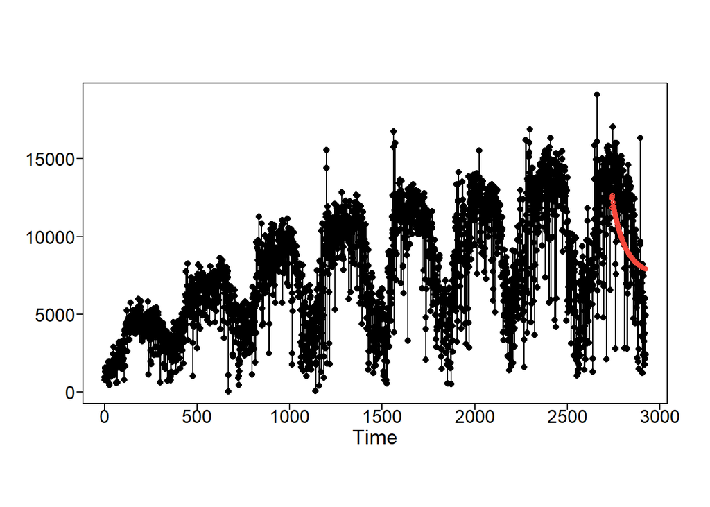

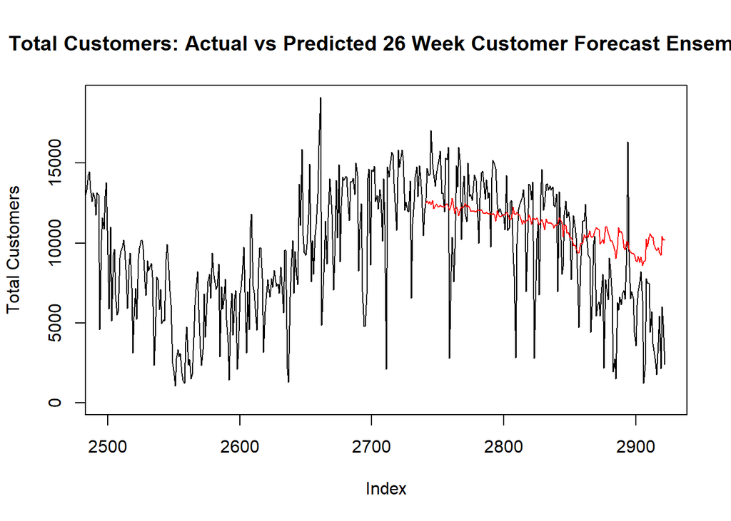

```r
#Ensemble
ensemble_182 = (pred_VAR_182$fcst$TotalCust[, 1] + fore_mlp_182$mean + preds_ar_182$f) / 3

#Plot
plot(BikeSharing$total_cust, type = "l", xlim = c(2500, nrow(BikeSharing)), ylab = "Total Customers", main = "Total Customers: Actual vs Predicted 26 Week Customer Forecast Ensemble")
lines((nrow(BikeSharing) - 181):nrow(BikeSharing), ensemble_182, type = "l", col = "red")
```

```r
ASE_ensemble_182 = mean((tail(BikeSharing$total_cust, 182) - ensemble_182)^2)
ASE_ensemble_182
```

```
## [1] 11486950
```

```r
preds_ar_7 = fore.arma.wge(BikeSharing$total_cust,
    phi = fit_ar$phi, n.ahead = 7,
    lastn = TRUE, limits = FALSE)
```

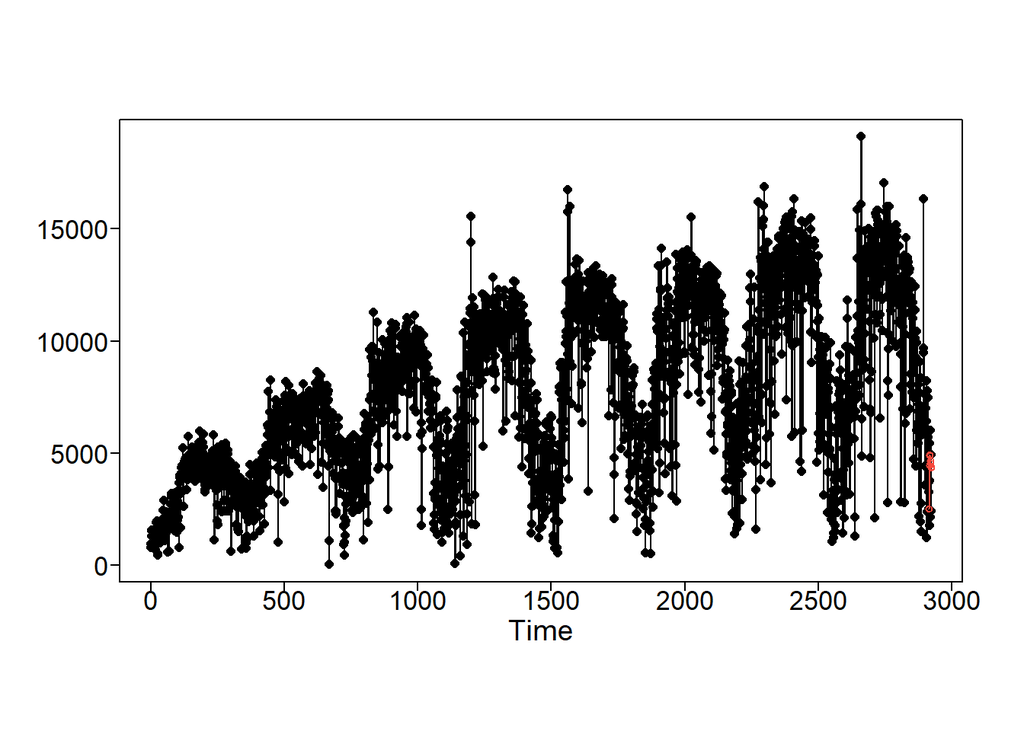

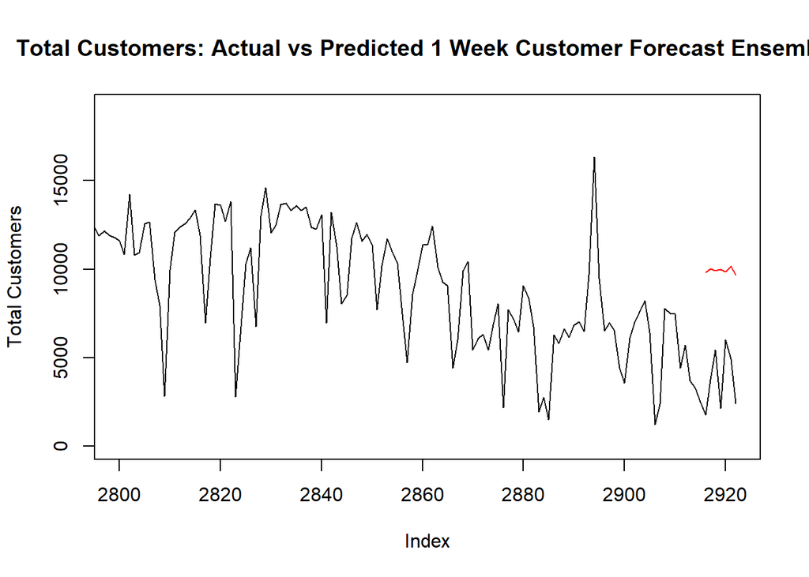

```r
#Ensemble
ensemble_7 = (pred_VAR_7$fcst$TotalCust[, 1] + fore_mlp_7$mean + preds_ar_7$f) / 3

#Plot
plot(BikeSharing$total_cust, type = "l", xlim = c(2800, nrow(BikeSharing)), ylab = "Total Customers", main = "Total Customers: Actual vs Predicted 1 Week Customer Forecast Ensemble")
lines((nrow(BikeSharing) - 6):nrow(BikeSharing), ensemble_7, type = "l", col = "red")
```

```r
ASE_ensemble_7 = mean((tail(BikeSharing$total_cust, 7) - ensemble_7)^2)
ASE_ensemble_7
```

```
## [1] 40192814
```